# Exercise 4

2021-11-01

# 1 Exercise 4

```r
#settings and libraries
knitr::opts_chunk$set(message = FALSE, warning = FALSE)
library(tidyverse)
library(nullabor)
library(broom)
library(DT)
```

```r
#read data
Cholesterol <- read.csv("data/Cholesterol_R.csv")
visinf_results <- read_csv("data/visinf-results.csv")
```

## 1.1 a.

Conduct a two-sample t-test and a Wilcoxon rank sum test to compare the mean cholesterol reduction between the margarine brands after 4 weeks. What graphics best compares these measurements across the brands? What do you conclude from the results of the tests and your graphics?

```r
#mutate diff column for the difference after 4 weeks
Cholesterol <- Cholesterol %>%
  mutate(Difference = Before - After4weeks)

#t-test
with(Cholesterol,
  t.test(Difference[Margarine=="A"], Difference[Margarine=="B"])) %>%
  tidy() %>%
  rename(mean.a = estimate1,
         mean.b = estimate2) %>%
  mutate_if(is.numeric, ~round(., 4)) %>%
  datatable()
```

|  | estimate | mean.a | mean.b | statistic | p.value | parameter | conf.low | conf.high | method | alternative |
| --- | --- | --- | --- | --- | --- | --- | --- | --- | --- | --- |
| 1 | -0.1611 | 0.4856 | 0.6467 | -2.5186 | 0.0229 | 15.9339 | -0.2968 | -0.0255 | Welch Two Sample t-test | two.sided |

Based on the results from the t-test, it is found that the difference of mean of margarine a and b is approximately 0.16. The p-value also indicates that the null hypothesis can be rejected in confidence level is 95%.

```r
#wilcoxon-test
with(Cholesterol,
  wilcox.test(Difference[Margarine=="A"], Difference[Margarine=="B"], conf.int = TRUE,
              corr = TRUE)) %>%
  tidy() %>%
  mutate_if(is.numeric, ~round(., 4)) %>%
  datatable()
```

|  | estimate | statistic | p.value | conf.low | conf.high | method | alternative |
| --- | --- | --- | --- | --- | --- | --- | --- |
| 1 | -0.17 | 16 | 0.0339 | -0.3 | -0.01 | Wilcoxon rank sum test with continuity correction | two.sided |

Based on the results from the wilcoxon test, it is found that the difference of mean of margarine a and b is approximately 0.17 which is very close to the results from the t-test. The p-value also indicate that the null hypothesis can be rejected in 5% significant level.

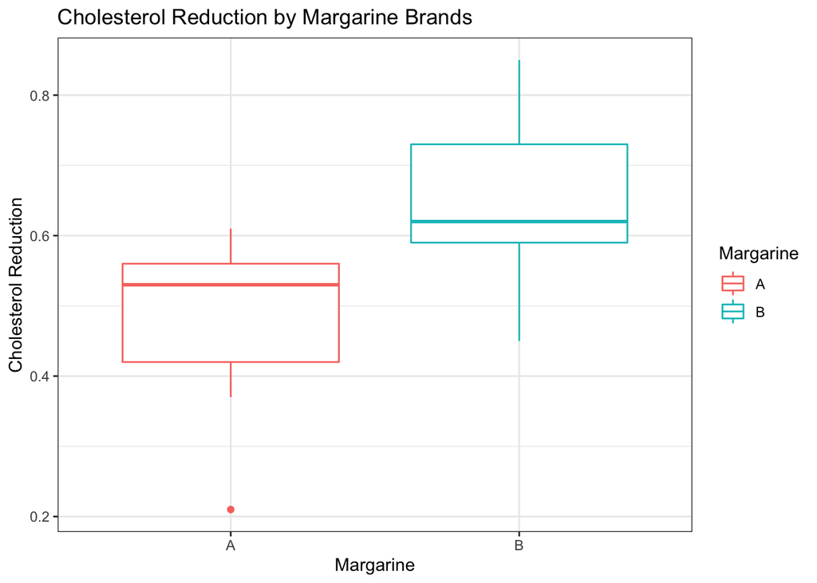

```r
Cholesterol%>%
  ggplot(aes(x = Margarine,
             y = Difference,
             color = Margarine)) +
  geom_boxplot() +
  labs(x = "Margarine",
       y = "Cholesterol Reduction",
       title = "Cholesterol Reduction by Margarine Brands") +
  theme_bw()
```

Since there are not many outliers, it is easier to compare their difference by mean value. And it is obvious that the cholesterol reduction of margarine B is higher than A. It is because B’s lower quantile is even higher than A’s upper quantile.